# Desafio Kaggle - UCI HEART DISEASES

# Daniel Malheiros

```python
from IPython.display import HTML

HTML('''<script>
code_show=true;
function code_toggle() {
 if (code_show){
 $('div.input').hide();
 } else {
 $('div.input').show();
 }
 code_show = !code_show
}
$( document ).ready(code_toggle);
</script>
<form action="javascript:code_toggle()"><input type="submit" value="Clique para mostrar codigo."></form>''')
```

# Lendo Dataset, fazendo imports e primeiras impressões:

Heart Disease Data Set:

https://www.kaggle.com/ronitf/heart-disease-uci

https://www.kaggle.com/cherngs/heart-disease-cleveland-uci

https://archive.ics.uci.edu/ml/datasets/Heart+Disease

```python
import pandas as pd
import numpy as np
import matplotlib.pyplot as plt
import matplotlib.patches as mpatches
import seaborn as sns

# metricas e processamento
from sklearn.preprocessing import StandardScaler
from sklearn.model_selection import train_test_split
from sklearn.model_selection import cross_val_score
from sklearn.metrics import accuracy_score, confusion_matrix, classification_report
from sklearn.metrics import roc_curve, auc
from sklearn import preprocessing
from sklearn.metrics import mean_squared_error
import shap

# modelos
from sklearn.dummy import DummyClassifier
from sklearn.neighbors import KNeighborsClassifier
from sklearn.model_selection import GridSearchCV
from sklearn.ensemble import RandomForestClassifier
from sklearn.linear_model import LogisticRegression
from sklearn.svm import SVC
from sklearn.ensemble import GradientBoostingClassifier
```

O dataset original possui 76 features, que foram reduzidas a um subset com apenas 14 para o desafio Kaggle (por diversos motivos como features inconsistentes e grande quantidade de dados faltantes). O objetivo principal do desafio é classificar pacientes como 0 (saudaveis) e 1 (com doença cardíaca).

Existem também diversos objetivos secundários, como limpeza dos dados, visualização e obtenção de insights e feature engineering. Nesse notebook, passaremos por todas estas etapas e tentaremos classificar corretamente nossa variável alvo usando modelos KNN, Random Forest, Regressão Logística, SVM e GBM.

Por fim, utilizaremos valores SHAP para interpretar as variáveis mais e menos influentes para cada modelo.

A dificuldade de obter dados confiáveis é um problema recorrente. Utilizando os valores SHAP, treinaremos os mesmos modelos após remover suas três variáveis consideradas menos influentes e analisaremos seu rendimento. Se recebermos métricas iguais ou melhores nestes novos modelos em comparação com os primeiros, podemos defender que, no contexto do dataset de Cleveland, mais features não necessariamente trazem melhores resultados, teoricamente poupando a necessidade do hospital de obter e armazenar certos tipos de dado que não contribuem para o modelo.

```python
# Lendo o dataset e traduzindo colunas:

columns = ['age', 'sex', 'cp', 'trestbps', 'chol', 'fbs', 'restecg', 'thalach',
           'exang', 'oldpeak', 'slope', 'ca', 'thal', 'condition']

df = pd.read_csv(r'C:\Users\Daniel O. Malheiros\Downloads\processed.cleveland.data', names=columns)


df = df.rename(columns={'age':'idade',
                  'sex':'sexo',
                  'cp':'dor toracica',
                  'trestbps':'pressão (repouso)',
                  'chol':'colesterol',
                  'fbs':'glicose em jejum',
                  'restecg':'ECG em repouso',
                  'thalach':'frequência cardíaca máxima (stress)',
                  'exang':'angina (stress)',
                  'oldpeak':'valor ST',
                  'slope':'curva ST',
                  'ca':'num vasos',
                  'thal':'defeito de perfusão',
                  'condition':'condicao'})
```

```python
df.head()
```

|  | idade | sexo | dor toracica | pressão (repouso) | colesterol | glicose em jejum | ECG em repouso | frequência cardíaca máxima (stress) | angina (stress) | valor ST | curva ST | num vasos | defeito de perfusão | condicao |
| --- | --- | --- | --- | --- | --- | --- | --- | --- | --- | --- | --- | --- | --- | --- |
| 0 | 63.0 | 1.0 | 1.0 | 145.0 | 233.0 | 1.0 | 2.0 | 150.0 | 0.0 | 2.3 | 3.0 | 0.0 | 6.0 | 0 |
| 1 | 67.0 | 1.0 | 4.0 | 160.0 | 286.0 | 0.0 | 2.0 | 108.0 | 1.0 | 1.5 | 2.0 | 3.0 | 3.0 | 2 |
| 2 | 67.0 | 1.0 | 4.0 | 120.0 | 229.0 | 0.0 | 2.0 | 129.0 | 1.0 | 2.6 | 2.0 | 2.0 | 7.0 | 1 |
| 3 | 37.0 | 1.0 | 3.0 | 130.0 | 250.0 | 0.0 | 0.0 | 187.0 | 0.0 | 3.5 | 3.0 | 0.0 | 3.0 | 0 |
| 4 | 41.0 | 0.0 | 2.0 | 130.0 | 204.0 | 0.0 | 2.0 | 172.0 | 0.0 | 1.4 | 1.0 | 0.0 | 3.0 | 0 |

Formato do dataframe:

```python
df.shape
```

```
(303, 14)
```

Colunas (features e variavel alvo):

```python
df.columns
```

```
Index(['idade', 'sexo', 'dor toracica', 'pressão (repouso)', 'colesterol',
       'glicose em jejum', 'ECG em repouso',
       'frequência cardíaca máxima (stress)', 'angina (stress)', 'valor ST',
       'curva ST', 'num vasos', 'defeito de perfusão', 'condicao'],
      dtype='object')
```

```python
df.info()
```

```
<class 'pandas.core.frame.DataFrame'>
RangeIndex: 303 entries, 0 to 302
Data columns (total 14 columns):
 #   Column                               Non-Null Count  Dtype
---  ------                               --------------  -----
 0   idade                                303 non-null    float64
 1   sexo                                 303 non-null    float64
 2   dor toracica                         303 non-null    float64
 3   pressão (repouso)                    303 non-null    float64
 4   colesterol                           303 non-null    float64
 5   glicose em jejum                     303 non-null    float64
 6   ECG em repouso                       303 non-null    float64
 7   frequência cardíaca máxima (stress)  303 non-null    float64
 8   angina (stress)                      303 non-null    float64
 9   valor ST                             303 non-null    float64
 10  curva ST                             303 non-null    float64
 11  num vasos                            303 non-null    object
 12  defeito de perfusão                  303 non-null    object
 13  condicao                             303 non-null    int64
dtypes: float64(11), int64(1), object(2)
memory usage: 33.3+ KB
```

Nosso dataset possui 303 linhas, com 13 features e uma coluna representando a variável alvo (condição), somando 14. De cara podemos ver que algumas variáveis estão com o tipo de dado errado (por exemplo, condição deveria ser uma categoria, idade um integer, etc). Vamos ajustar isso.

# Ajustando variaveis e seus dtypes

Antes de começarmos, vamos dar uma arrumada em nosso dataset.

Alguns tipos de dados estão incorretos, enquanto outros estão pouco claros (categorias como números pouco representativos). Para mais informações sobre os dados originais e seus formatos, entre em https://archive.ics.uci.edu/ml/datasets/Heart+Disease

No dataset original, a variável alvo ('condicao') possui os valores 0, 1, 2, 3 e 4, sendo 0 ausência de doença e 1, 2, 3 e 4 presença de doença.

O dataset não deixa claro a diferença entre os valores positivos para doença cardíaca (suponho que gravidade). Transformarei esses valores para trabalharmos com uma classificação binária, ou seja, somente 0 (ausência de doença cardíaca) e 1 (presença de doença cardíaca)

```python
df['condicao'] = df['condicao'].replace({1:1, 2:1, 3:1, 4:1})
df['condicao'] = pd.Categorical(df['condicao'])
df['condicao'].unique()
```

```
[0, 1]
Categories (2, int64): [0, 1]
```

Transformando variável Idade em um int:

```python
df['idade'] = df['idade'].astype('int')
df['idade'].dtype
```

```
dtype('int32')
```

Transformando variavel binaria de sexo em categorica com nomes "homem" e "mulher" para facilitar visualizações e entendimento do dataset:

0 = Mulher

1 = Homem

```python
df['sexo'] = df['sexo'].replace({0:'mulher', 1:'homem'})

df['sexo'] = pd.Categorical(df['sexo'])

df['sexo'].unique()
```

```
['homem', 'mulher']
Categories (2, object): ['homem', 'mulher']
```

Transformando a variável "dor toracica" em categorica, explicitando nomes das categorias:

1 = Angina típica

2 = Angina Atípica

3 = Dor não-anginosa

4 = Assintomático

```python
df['dor toracica'] = df['dor toracica'].replace({1:'angina tipica',
                           2:'angina atipica',
                           3:'dor não-anginal',
                           4:'assintomatico'})

df['dor toracica'] = pd.Categorical(df['dor toracica'])

df['dor toracica'].unique()
```

```
['angina tipica', 'assintomatico', 'dor não-anginal', 'angina atipica']
Categories (4, object): ['angina tipica', 'assintomatico', 'dor não-anginal', 'angina atipica']
```

Transformando variável "Glicose em jejum" em categórica, explicitando nomes das categorias:

0 = valor menor que 120mg/dl

1 = valor maior que 120mg/dl

```python
df['glicose em jejum'] = df['glicose em jejum'].replace({0:'menor que 120mg',1:'maior que 120mg'})

df['glicose em jejum'] = pd.Categorical(df['glicose em jejum'])

df['glicose em jejum'].unique()
```

```
['maior que 120mg', 'menor que 120mg']
Categories (2, object): ['maior que 120mg', 'menor que 120mg']
```

Transformando variável "ECG em repouso" em categórica. Aqui manterei os valores como números, pois é importante que haja a intuição que quanto maior o valor, mais grave o quadro (mais a frente, na sessão "Entendendo as variáveis", falo mais sobre):

0 = Normal

1 = Anormalidade no segmento ST ou onda T do eletrocardiograma

2 = Hipertrofia ventricular segundo critério de Estes

```python
df['ECG em repouso'] = pd.Categorical(df['ECG em repouso'])
df['ECG em repouso'].unique()
```

```
[2.0, 0.0, 1.0]
Categories (3, float64): [2.0, 0.0, 1.0]
```

Transformando a variável "Angina (stress)" em categorica, explicitando nomes das categorias:

0 = Sem angina durante estresse

1 = Com angina durante estresse

```python
df['angina (stress)'] = df['angina (stress)'].replace({0:'sem angina (stress)', 1: 'com angina (stress)'})

df['angina (stress)'] = pd.Categorical(df['angina (stress)'])

df['angina (stress)'].unique()
```

```
['sem angina (stress)', 'com angina (stress)']
Categories (2, object): ['sem angina (stress)', 'com angina (stress)']
```

Transformando variável Curva ST em categorica, explicitando nomes das categorias:

1 = curva crescente

2 = segmento reto

3 = curva decrescente

```python
df['curva ST'] = df['curva ST'].replace({1:'ST crescente',
                       2:'ST reto',
                       3:'ST decrescente'})

df['curva ST'] = pd.Categorical(df['curva ST'])

df['curva ST'].unique()
```

```
['ST decrescente', 'ST reto', 'ST crescente']
Categories (3, object): ['ST decrescente', 'ST reto', 'ST crescente']
```

Transformando a variável "Defeito de perfusão" em categórica, tratando o caracter especial "?", que está representando valor faltante e explicitando nomes das categorias:

3 = Sem presença

6 = Defeitos fixos

7 = Defeitos reversíveis

? = Missing Value

```python
df['defeito de perfusão'] = df['defeito de perfusão'].replace('?',np.nan)

df['defeito de perfusão'] = pd.to_numeric(df['defeito de perfusão'])
df['defeito de perfusão'] = df['defeito de perfusão'].replace({3:'sem defeito', 6:'defeito fixo', 7:'defeixo reversivel'})

df['defeito de perfusão'] = pd.Categorical(df['defeito de perfusão'])

df['defeito de perfusão'].unique()
```

```
['defeito fixo', 'sem defeito', 'defeixo reversivel', NaN]
Categories (3, object): ['defeito fixo', 'sem defeito', 'defeixo reversivel']
```

```python
df['num vasos'].unique()
```

```
array(['0.0', '3.0', '2.0', '1.0', '?'], dtype=object)
```

A variável "num vasos" também possui o carácter "?" representando valores faltantes, vamos ajustar:

(manterei essa variável como numerica por enquanto, explicarei mais a frente)

```python
df['num vasos'] = df['num vasos'].replace('?',np.nan)
df['num vasos'] = pd.to_numeric(df['num vasos'])

df['num vasos'].unique()
```

```
array([ 0.,  3.,  2.,  1., nan])
```

```python
df.info()
```

```
<class 'pandas.core.frame.DataFrame'>
RangeIndex: 303 entries, 0 to 302
Data columns (total 14 columns):
 #   Column                               Non-Null Count  Dtype
---  ------                               --------------  -----
 0   idade                                303 non-null    int32
 1   sexo                                 303 non-null    category
 2   dor toracica                         303 non-null    category
 3   pressão (repouso)                    303 non-null    float64
 4   colesterol                           303 non-null    float64
 5   glicose em jejum                     303 non-null    category
 6   ECG em repouso                       303 non-null    category
 7   frequência cardíaca máxima (stress)  303 non-null    float64
 8   angina (stress)                      303 non-null    category
 9   valor ST                             303 non-null    float64
 10  curva ST                             303 non-null    category
 11  num vasos                            299 non-null    float64
 12  defeito de perfusão                  301 non-null    category
 13  condicao                             303 non-null    category
dtypes: category(8), float64(5), int32(1)
memory usage: 16.4 KB
```

Pronto! Nossas variáveis estão prontas para darmos continuidade ao projeto.

# Identificando valores faltantes e duplicatas:

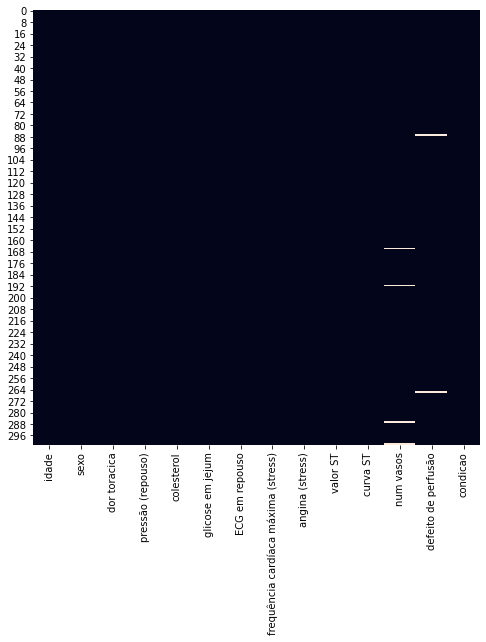

```python
plt.figure(figsize=(8,8))
sns.heatmap(df.isnull(), cbar=False)
```

```python
df.isnull().sum()
```

```
idade                                  0
sexo                                   0
dor toracica                           0
pressão (repouso)                      0
colesterol                             0
glicose em jejum                       0
ECG em repouso                         0
frequência cardíaca máxima (stress)    0
angina (stress)                        0
valor ST                               0
curva ST                               0
num vasos                              4
defeito de perfusão                    2
condicao                               0
dtype: int64
```

Aparentemente temos 6 valores faltantes em nosso df, 4 na coluna "num vasos" e 2 na coluna "defeito de perfusão".

```python
df[df['num vasos'].isnull() == True]
```

|  | idade | sexo | dor toracica | pressão (repouso) | colesterol | glicose em jejum | ECG em repouso | frequência cardíaca máxima (stress) | angina (stress) | valor ST | curva ST | num vasos | defeito de perfusão | condicao |
| --- | --- | --- | --- | --- | --- | --- | --- | --- | --- | --- | --- | --- | --- | --- |
| 166 | 52 | homem | dor não-anginal | 138.0 | 223.0 | menor que 120mg | 0.0 | 169.0 | sem angina (stress) | 0.0 | ST crescente | NaN | sem defeito | 0 |
| 192 | 43 | homem | assintomatico | 132.0 | 247.0 | maior que 120mg | 2.0 | 143.0 | com angina (stress) | 0.1 | ST reto | NaN | defeixo reversivel | 1 |
| 287 | 58 | homem | angina atipica | 125.0 | 220.0 | menor que 120mg | 0.0 | 144.0 | sem angina (stress) | 0.4 | ST reto | NaN | defeixo reversivel | 0 |
| 302 | 38 | homem | dor não-anginal | 138.0 | 175.0 | menor que 120mg | 0.0 | 173.0 | sem angina (stress) | 0.0 | ST crescente | NaN | sem defeito | 0 |

```python
df[df['defeito de perfusão'].isnull() == True]
```

|  | idade | sexo | dor toracica | pressão (repouso) | colesterol | glicose em jejum | ECG em repouso | frequência cardíaca máxima (stress) | angina (stress) | valor ST | curva ST | num vasos | defeito de perfusão | condicao |
| --- | --- | --- | --- | --- | --- | --- | --- | --- | --- | --- | --- | --- | --- | --- |
| 87 | 53 | mulher | dor não-anginal | 128.0 | 216.0 | menor que 120mg | 2.0 | 115.0 | sem angina (stress) | 0.0 | ST crescente | 0.0 | NaN | 0 |
| 266 | 52 | homem | assintomatico | 128.0 | 204.0 | maior que 120mg | 0.0 | 156.0 | com angina (stress) | 1.0 | ST reto | 0.0 | NaN | 1 |

Com essa checagem, percebemos que todos os valores faltantes estão em linhas diferentes uns dos outros. As linhas com valores faltantes são:

```python
print('Linhas com valores faltantes (%): ' + str(round(6 * 100 / len(df),4)) + '%')
```

```
Linhas com valores faltantes (%): 1.9802%
```

Com este cálculo, sabemos que estas linhas representam somente 1,98% de nosso dataframe. Como é um valor baixo, vou optar dropar estes valores em vez de tentar preenchê-los.

```python
df = df.dropna()
df.shape
```

```
(297, 14)
```

```python
# Checando duplicatas
len(df[df.duplicated() == True])
```

```
0
```

Possuímos 0 duplicatas em nosso dataframe. Que bom!

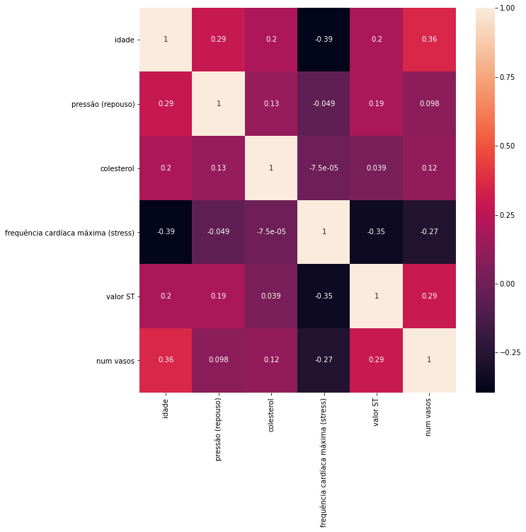

```python
plt.figure(figsize=(10,10))
sns.heatmap(df.corr(), annot=True)
```

Podemos ver com este heatmap que nossas variáveis de valor contínuo não possuem correlações muito altas (positivas ou negativas) entre si, o que é ótimo! Isso nos salva de um possível problema de multicolinearidade que poderia atrapalhar nosso modelo.

# Procurando por Outliers

```python
df.describe().T
```

|  | count | mean | std | min | 25% | 50% | 75% | max |
| --- | --- | --- | --- | --- | --- | --- | --- | --- |
| idade | 297.0 | 54.542088 | 9.049736 | 29.0 | 48.0 | 56.0 | 61.0 | 77.0 |
| pressão (repouso) | 297.0 | 131.693603 | 17.762806 | 94.0 | 120.0 | 130.0 | 140.0 | 200.0 |
| colesterol | 297.0 | 247.350168 | 51.997583 | 126.0 | 211.0 | 243.0 | 276.0 | 564.0 |
| frequência cardíaca máxima (stress) | 297.0 | 149.599327 | 22.941562 | 71.0 | 133.0 | 153.0 | 166.0 | 202.0 |
| valor ST | 297.0 | 1.055556 | 1.166123 | 0.0 | 0.0 | 0.8 | 1.6 | 6.2 |
| num vasos | 297.0 | 0.676768 | 0.938965 | 0.0 | 0.0 | 0.0 | 1.0 | 3.0 |

Vamos checar se existem outliers em nossas variáveis com valores contínuos (idade, pressão (repouso), colesterol, frequência cardíaca máxima (stress), valor ST). Não incluirei a coluna 'num vasos' pois mesmo tendo a mantido como numérica, sabemos que nela só possuímos os valores 0, 1, 2 e 3.

Existem diversas formas de procurar outliers. Vamos utilizar os boxplots (IQR) para investigar.

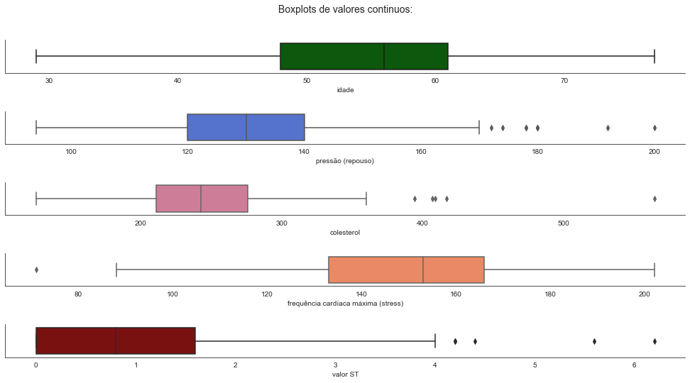

```python
sns.set_style('white')

fig, ax = plt.subplots(5,1, figsize=(14,8))

ax[0].set_title('Boxplots de valores continuos:\n\n', fontsize=14)

sns.boxplot(x='idade', data=df, ax=ax[0], color='darkgreen')
sns.boxplot(x='pressão (repouso)', data=df, ax=ax[1], color='royalblue')
sns.boxplot(x='colesterol', data=df, ax=ax[2], color='palevioletred')
sns.boxplot(x='frequência cardíaca máxima (stress)', data=df, ax=ax[3], color='coral')
sns.boxplot(x='valor ST', data=df, ax=ax[4], color='darkred')



plt.tight_layout(pad=2.5)
sns.despine()
plt.show()
```

Podemos perceber alguns outliers em todas as colunas contínuas exceto Idade.

(Q1 = primeiro quartil, Q3 = terceiro quartil, IQR = intervalo interquartil)

Utilizaremos a função abaixo, que facilitará nossos cálculos:

```python
# função para identificar e remover outliers com mais facilidade

def outliers(df_out, drop = False):
    for each_feature in df_out.columns:
        feature_data = df_out[each_feature]
        Q1 = np.percentile(feature_data, 25.) # 25th percentil
        Q3 = np.percentile(feature_data, 75.) # 75th percentil
        IQR = Q3-Q1 #Interquartile Range
        outlier_step = IQR * 1.5
        outliers = feature_data.loc[~((feature_data >= Q1 - outlier_step) & (feature_data <= Q3 + outlier_step))].index.tolist()
        if not drop:
            print('Coluna: {}\nNo de Outliers: {}\nIndex: {}\n'.format(each_feature, len(outliers), outliers))
        if drop:
            df.drop(outliers, inplace = True, errors = 'ignore')
            print('Coluna: {}\nOutliers removidos\n'.format(each_feature))
```

```python
df_outliers = df[['pressão (repouso)', 'colesterol', 'frequência cardíaca máxima (stress)', 'valor ST']]
```

```python
outliers(df_outliers)
```

```
Coluna: pressão (repouso)
No de Outliers: 9
Index: [14, 83, 126, 172, 183, 188, 201, 213, 231]

Coluna: colesterol
No de Outliers: 5
Index: [48, 121, 152, 173, 181]

Coluna: frequência cardíaca máxima (stress)
No de Outliers: 1
Index: [245]

Coluna: valor ST
No de Outliers: 5
Index: [91, 123, 183, 191, 285]
```

Ok! Identificados os valores e seus respectivos índices no dataframe, podemos finalmente removê-los para ter resultados estatisticamente mais significantes.

```python
df.shape
```

```
(297, 14)
```

```python
outliers(df_outliers, drop=True)
```

```
Coluna: pressão (repouso)
Outliers removidos

Coluna: colesterol
Outliers removidos

Coluna: frequência cardíaca máxima (stress)
Outliers removidos

Coluna: valor ST
Outliers removidos
```

```python
df.shape
```

```
(278, 14)
```

```python
df.head()
```

|  | idade | sexo | dor toracica | pressão (repouso) | colesterol | glicose em jejum | ECG em repouso | frequência cardíaca máxima (stress) | angina (stress) | valor ST | curva ST | num vasos | defeito de perfusão | condicao |
| --- | --- | --- | --- | --- | --- | --- | --- | --- | --- | --- | --- | --- | --- | --- |
| 0 | 63 | homem | angina tipica | 145.0 | 233.0 | maior que 120mg | 2.0 | 150.0 | sem angina (stress) | 2.3 | ST decrescente | 0.0 | defeito fixo | 0 |
| 1 | 67 | homem | assintomatico | 160.0 | 286.0 | menor que 120mg | 2.0 | 108.0 | com angina (stress) | 1.5 | ST reto | 3.0 | sem defeito | 1 |
| 2 | 67 | homem | assintomatico | 120.0 | 229.0 | menor que 120mg | 2.0 | 129.0 | com angina (stress) | 2.6 | ST reto | 2.0 | defeixo reversivel | 1 |
| 3 | 37 | homem | dor não-anginal | 130.0 | 250.0 | menor que 120mg | 0.0 | 187.0 | sem angina (stress) | 3.5 | ST decrescente | 0.0 | sem defeito | 0 |
| 4 | 41 | mulher | angina atipica | 130.0 | 204.0 | menor que 120mg | 2.0 | 172.0 | sem angina (stress) | 1.4 | ST crescente | 0.0 | sem defeito | 0 |

# Entendendo as variáveis com EDA

```python
# Função utilizada para apresentar valores em graficos de barra

def show_values_on_bars(axs):
    def _show_on_single_plot(ax):
        for p in ax.patches:
            _x = p.get_x() + p.get_width() / 2
            _y = p.get_y() + p.get_height()
            value = '{:.2f}'.format(p.get_height())
            ax.text(_x, _y, value, ha="center")

    if isinstance(axs, np.ndarray):
        for idx, ax in np.ndenumerate(axs):
            _show_on_single_plot(ax)
    else:
        _show_on_single_plot(axs)
```

**Condicao (condition)**

Nossa variável alvo, ou seja, presença ou não de doença cardíaca.

0 = Sem doença cardíaca

1 = Com doença cardíaca

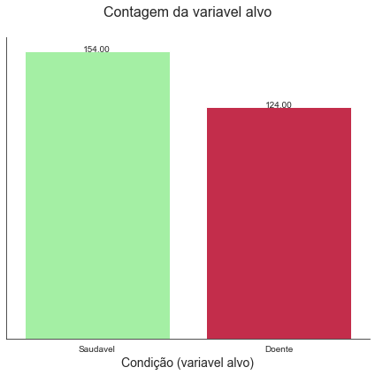

```python
sns.set_style('white')
plt.figure(figsize=(6,6))

colors = ['palegreen','crimson']
ax = sns.countplot(df['condicao'], palette=colors)
show_values_on_bars(ax)

plt.ylabel('')
plt.yticks(ticks=[])
plt.xticks(ticks=[0,1],labels=['Saudavel','Doente'])
plt.xlabel('Condição (variavel alvo)', fontdict={'size':14})
plt.title('Contagem da variavel alvo\n', fontdict={'size':16})


sns.despine()
plt.tight_layout()
plt.show()
```

Nossas variáveis alvo estão relativamente balanceadas, com 154 pacientes 0 (sem doença) e 124 pacientes 1 (com doença).

**Sexo (sex):**

Sexo do paciente

Em média, homens sofrem seu primeiro ataque cardíaco aos 65 anos, enquanto a média de idade para mulheres é em torno de 72. Homens tendem a apresentar risco aumentado para doenças cardiovasculares se comparado às mulheres. Fatores comportamentais, biológicos e sociais podem estar por trás dessa diferença.

Fontes:

https://www.hopkinsmedicine.org/health/wellness-and-prevention/special-heart-risks-for-men

https://www.health.harvard.edu/heart-health/the-heart-attack-gender-gap

Vamos contar quantos pacientes saudaveis e doentes temos para cada sexo:

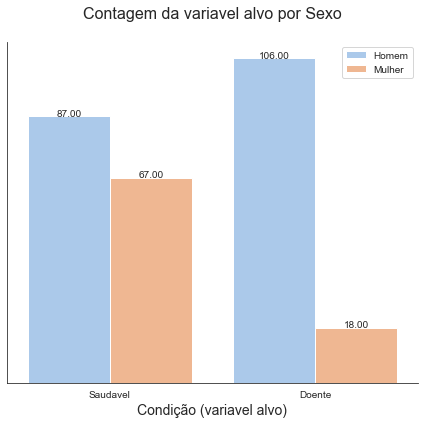

```python
sns.set_style('white')
plt.figure(figsize=(6,6))

ax = sns.countplot('condicao',hue='sexo',data=df, palette='pastel')
show_values_on_bars(ax)

plt.ylabel('')
plt.xlabel('Condição (variavel alvo)', fontdict={'size':14})
plt.title('Contagem da variavel alvo por Sexo\n', fontdict={'size':16})
plt.yticks(ticks=[])
plt.xticks(ticks=[0,1],labels=['Saudavel','Doente'])
plt.legend(['Homem','Mulher'])
sns.despine()
plt.tight_layout()
plt.show()
```

Na condição Saudavel (0), os valores entre sexos são relativamente balanceados, porem na condição Doente (1), temos muito mais homens do que mulheres, o que significa que a variavel sexo (especificamente: ser homem) é um de fato fator de risco para doenças cardiacas (corroborando com a literatura medica).

Importante notar que nosso dataset possui aproximadamente o dobro de pacientes homens que mulheres.

```python
df['sexo'].value_counts()
```

```
homem     193
mulher     85
Name: sexo, dtype: int64
```

**Idade (age):**

Idade do paciente em anos.

Com o avanço dos anos, o sistema cardiovascular passa por uma série de alterações, tais como arteriosclerose (endurecimento, perda de elasticidade e espessamento progressivo das paredes das artérias), diminuição da distensibilidade da aorta e das grandes artérias, comprometimento da condução cardíaca e redução na função barorreceptora (regulação de pressão cardíaca).

A correlação entre idade avançada e risco de doenças cardiovasculares já é bem conhecida pela literatura médica, porém, diversos fatores como estilo de vida, comorbidades e histórico familiar podem influenciar esta correlação. Infelizmente não possuímos todos estes dados neste dataset.

Fonte: https://www.scielo.br/scielo.php?script=sci_arttext&pid=S0066-782X2002001500011&lng=pt&nrm=iso&tlng=pt

Vamos checar a distribuição da idade do dataset, tanto para pacientes saudáveis e pacientes com doenças cardíacas.

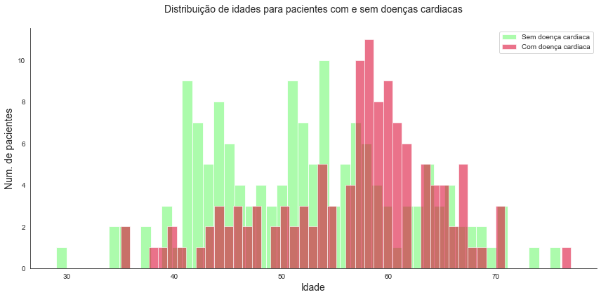

```python
sns.set_style('white')
plt.figure(figsize=(12,6))

sns.distplot(df[df['condicao'] == 0]['idade'], kde=False, bins=48, color='palegreen', hist_kws=dict(alpha=.8),label="Sem doença cardiaca")
sns.distplot(df[df['condicao'] == 1]['idade'], kde=False, bins=48, color='crimson', hist_kws=dict(alpha=.6),label="Com doença cardiaca")



plt.xlabel('Idade', fontdict={'size':14})
plt.ylabel('Num. de pacientes', fontdict={'size':14})

plt.title('Distribuição de idades para pacientes com e sem doenças cardiacas\n', fontdict={'size':14})
plt.legend()
sns.despine()
plt.tight_layout()
plt.show()
```

Podemos perceber com o histograma acima que a variável Idade provavelmente será um bom indicativo para nosso modelo, pois o grupo de pacientes que apresentou doença cardíaca tem uma distribuição de idade consideravelmente mais avançada. Também é possível notar que a maior parte dos casos positivos estão entre 55 e 62 anos aproximadamente.

```python
print(f"Mediana de idade para pacientes doentes: {df[df['condicao'] == 1]['idade'].median()}")
print(f"Mediana de idade para pacientes saudáveis: {df[df['condicao'] == 0]['idade'].median()}")
```

```
Mediana de idade para pacientes doentes: 58.0
Mediana de idade para pacientes saudáveis: 52.0
```

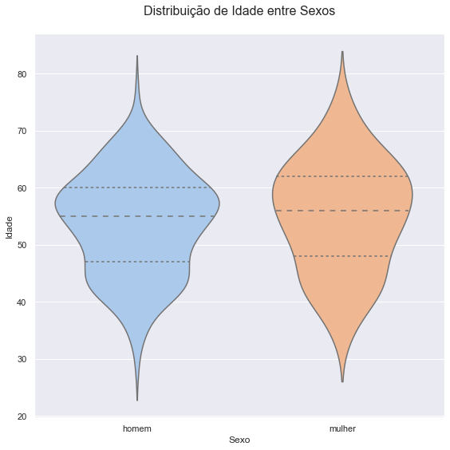

```python
sns.set()
plt.figure(figsize=(8,8))

sns.violinplot(x='sexo', y='idade', data=df, split=True, inner="quartile", palette='pastel')

plt.title('Distribuição de Idade entre Sexos\n', fontdict={'size':16})

plt.xlabel('Sexo',fontdict={'size':12})
plt.ylabel('Idade',fontdict={'size':12})
plt.tight_layout()

plt.show()
```

A distribuição de idades entre sexos parece ser parecida entre homens e mulheres, com a mediana por volta de 55 anos.

```python
print(f"Mediana de idade (mulheres): {df[df['sexo'] == 'mulher']['idade'].median()}")

print(f"Mediana de idade (homens): {df[df['sexo'] == 'homem']['idade'].median()}")
```

```
Mediana de idade (mulheres): 56.0
Mediana de idade (homens): 55.0
```

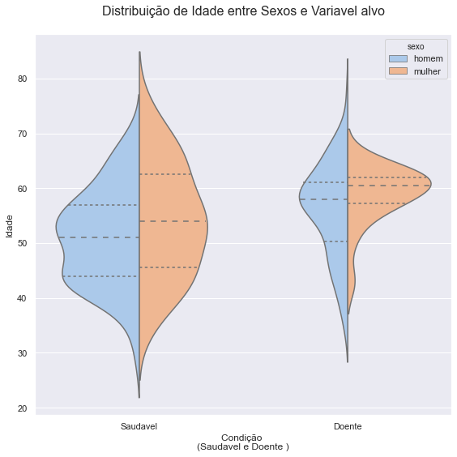

```python
sns.set()
plt.figure(figsize=(8,8))

sns.violinplot(x='condicao',y='idade', hue='sexo', data=df, split=True, inner="quartile", palette='pastel')

plt.title('Distribuição de Idade entre Sexos e Variavel alvo\n', fontdict={'size':16})
plt.xlabel('Condição \n(Saudavel e Doente )', fontdict={'size':12})
plt.ylabel('Idade', fontdict={'size':12})
plt.xticks(ticks=[0,1],labels=['Saudavel','Doente'])

plt.tight_layout()

plt.show()
```

```python
print(f"Mediana de idade (mulheres doentes): {df[(df['condicao'] == 1) & (df['sexo'] == 'mulher')]['idade'].median()}")
print(f"Mediana de idade (mulheres saudaveis): {df[(df['condicao'] == 0) & (df['sexo'] == 'mulher')]['idade'].median()}\n")

print(f"Mediana de idade (homens doentes): {df[(df['condicao'] == 1) & (df['sexo'] == 'homem')]['idade'].median()}")
print(f"Mediana de idade (homens saudaveis): {df[(df['condicao'] == 0) & (df['sexo'] == 'homem')]['idade'].median()}\n")
```

```
Mediana de idade (mulheres doentes): 60.5
Mediana de idade (mulheres saudaveis): 54.0

Mediana de idade (homens doentes): 58.0
Mediana de idade (homens saudaveis): 51.0
```

Podemos notar que mulheres tendem a ficar doentes mais velhas que homens.

**Dor Toracica (cp: chest pain type):**

Tipo de angina, se presente, nas categorias:

Angina típica

Angina Atípica

Dor não-anginal

Assintomático

Angina pectoris é a descrição utilizada para caracterizar a dor torácica causada pela falta de sangue (isquemia) que acomete o músculo cardíaco. A angina se manifesta como uma sensação de dor ou desconforto no centro do peito, de localização mal definida, mais comumente descrita como aperto, peso, sufocação, queimação ou estrangulamento. É importante notar que angina não é uma doença e sim um sintoma.

A classificação de angina é normalmente feita via anamnese (entrevista com paciente) em repouso, logo, espera-se que haja ruído dos dados.

Angina típica:

Presença dos três fatores abaixo:

a) Desconforto ou dor retroesternal

b) Piora com esforço e/ou estresse emocional

c) Alivia com repouso e/ou uso de nitroglicerina

Angina Atípica: Trata-se de angina atípica quando paciente apresenta somente dois dos três fatores citados acima.

Dor não-anginal: Dor de localização muito bem definida (apontada com a ponta de um dedo) ou de duração fugaz (alguns segundos apenas).

Assintomático: Sem presença de angina, o que não necessariamente significa ausência de patologia.

Fontes:

https://www.einstein.br/especialidades/cardiologia/doencas-sintomas/angina

https://www.heart.org/en/health-topics/heart-attack/angina-chest-pain

https://www.pfizer.com.br/sua-saude/coracao/angina

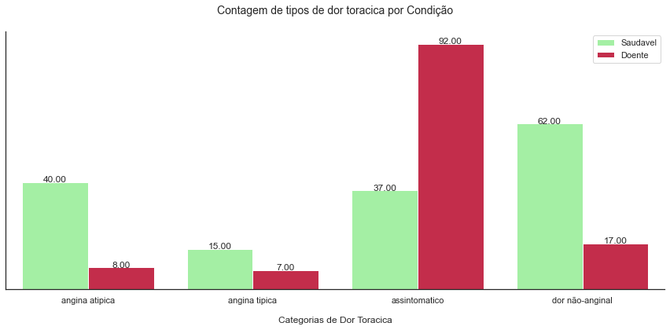

```python
sns.set_style('white')
plt.figure(figsize=(12,6))

ax = sns.countplot(df['dor toracica'], hue=df['condicao'], palette=colors)
show_values_on_bars(ax)

plt.title('Contagem de tipos de dor toracica por Condição\n', fontdict={'size':14})
plt.xlabel('\nCategorias de Dor Toracica', fontdict={'size':12})
plt.ylabel('')
plt.yticks(ticks=[])
plt.legend(['Saudavel','Doente'])
sns.despine()
plt.tight_layout()
plt.show()
```

Os dados acima são um pouco mais complicados.

Angina típica é a presença dos 3 fatores: desconforto ou dor retroesternal, piora com esforço e/ou estresse emocional e alivia com repouso e/ou uso de nitroglicerina. Já a angina atípica é a presença de somente dois destes. Logo, é natural que a diferença entre a quantidade de pacientes sem doença e com doença seja mais alta em pacientes que apresentam angina atípica (pois trata-se simplesmente de um menor acúmulo de sintomas que a angina típica). O mesmo pode ser dito para pacientes que apresentaram dor não-anginal, pois trata-se de um sintoma não específico para doenças cardíacas.

Logo, analisando os números:

Aprox. 16.6% dos pacientes que apresentaram angina atípica possuem doenças cardíacas

Aprox. 31.8% dos pacientes que apresentaram angina típica possuem doenças cardíacas

Aprox. 21.5% dos pacientes que apresentaram dor não anginal possuem doenças cardíacas

Existem aqui duas surpresas: a relação alta entre pacientes com doenças cardíacas assintomáticos e a quantidade de pacientes com sintomas que NÃO apresentaram doenças cardíacas.

É sempre complexo diagnosticar uma doença somente com a análise de um sintoma (neste caso, dor torácica). Temos poucas informações de como estes dados foram adquiridos e tendo em vista que são sintomas obtidos (geralmente) via anamnese, é necessário considerar a omissão (ou exagero) de informações por parte do paciente, resultando em falsos positivos e falsos negativos.

Apesar de surpreendente, é importante notar que há uma literatura extensa sobre análise de doenças cardíacas em pacientes previamente assintomáticos (principalmente em idosos e diabéticos).

(https://www.ncbi.nlm.nih.gov/books/NBK63673/)

**Pressão em repouso (trestbps):**

Pressão sanguínea arterial do paciente (mmHg) medida na chegada do paciente ao hospital.

Pressão alta pode ser um bom indicativo de doenças cardíacas. O valor considerado saudável varia muito entre do nascimento até os 18 anos, mas sendo rara a presença de doenças cardíacas nesta faixa etária e levando em conta que o paciente mais novo do dataset possui 29 anos, utilizarei como referência a tabela de classificação para pacientes 18+.

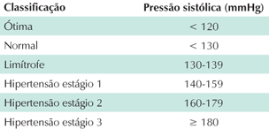

Fontes:

http://departamentos.cardiol.br/dha/consenso3/capitulo1.asp

https://doi.org/10.1590/S0066-782X2007001500012

Com essa tabela, podemos adicionar uma coluna classificatória para os valores de pressão arterial.

Faremos isso com o loop abaixo:

**Class pressão**

```python
print(df['pressão (repouso)'].max())
print(df['pressão (repouso)'].min())
```

```
170.0
94.0
```

```python
df['class pressão'] = ''

for idx, _ in df.iterrows():
    if df.loc[idx, 'pressão (repouso)'] < 120:
        df.loc[idx,'class pressão'] = 'otima'
    elif df.loc[idx, 'pressão (repouso)'] < 130:
        df.loc[idx,'class pressão'] = 'normal'
    elif 130 <= df['pressão (repouso)'][idx] <= 139:
        df.loc[idx,'class pressão'] = 'limitrofe'
    elif 140 <= df['pressão (repouso)'][idx] <= 159:
        df.loc[idx,'class pressão'] = 'hipertensao 1'
    elif 160 <= df['pressão (repouso)'][idx] <= 179:
        df.loc[idx,'class pressão'] = 'hipertensao 2'
    elif df['pressão (repouso)'][idx] >= 180:
        df.loc[idx,'class pressão'] = 'hipertensao 3'
```

```python
df['class pressão'] = pd.Categorical(df['class pressão'])
print(df['class pressão'].unique())
```

```
['hipertensao 1', 'hipertensao 2', 'normal', 'limitrofe', 'otima']
Categories (5, object): ['hipertensao 1', 'hipertensao 2', 'normal', 'limitrofe', 'otima']
```

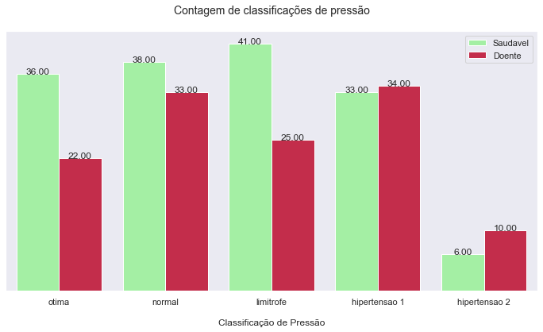

```python
sns.set()
plt.figure(figsize=(12,6))

ax = sns.countplot(df['class pressão'],hue=df['condicao'],
                   order=['otima','normal','limitrofe','hipertensao 1','hipertensao 2'],
                   palette=colors)

show_values_on_bars(ax)

plt.ylabel('')
plt.xlabel('\nClassificação de Pressão')
plt.title('Contagem de classificações de pressão\n', fontdict={'size':14})
plt.yticks(ticks=[])
plt.legend(['Saudavel','Doente'])

plt.show()
```

O resultado deste gráfico corrobora parcialmente com o que esperávamos:

As barras de pressão ótima, normal e limítrofe possuem mais pacientes saudáveis do que doentes, enquanto as barras de hipertensão possuem mais pacientes doentes que saudáveis, apesar da diferença na barra "hipertensão 1" ser ínfima. O "problema" é que a maioria das classificações possuem pouca diferença entre os grupos saudáveis e doentes e as que possuem diferenças significativas nos trazem informações estranhas, por exemplo, a diferença entre saudáveis e não-saudáveis é maior em pacientes com pressão limítrofe do que saudável.

Os dados contínuos de pressão são capazes de nos dar insights mais precisos. Vamos dar uma olhada.

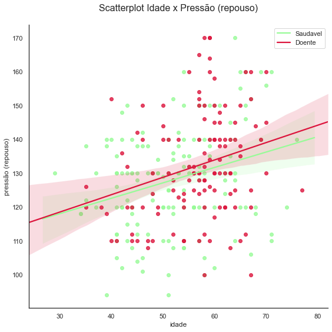

```python
sns.set_style('white')

sns.lmplot(x='idade',y='pressão (repouso)', data=df, hue='condicao', height=8, legend=False, palette=colors)

plt.title('Scatterplot Idade x Pressão (repouso)\n', fontdict={'size':16})


plt.legend(['Saudavel','Doente'])
sns.despine()
plt.tight_layout()
plt.show()
```

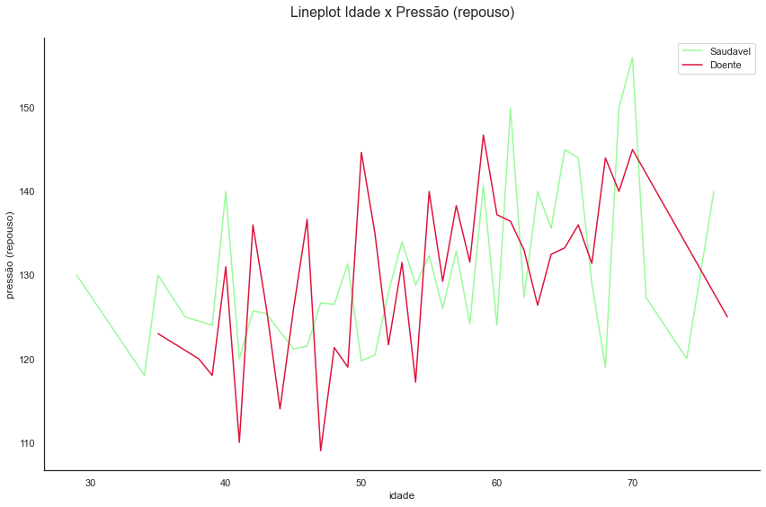

```python
sns.set_style('white')
plt.figure(figsize=(12,8))
sns.lineplot(x='idade',y='pressão (repouso)', data=df, hue='condicao', palette=colors, ci=None)
plt.title('Lineplot Idade x Pressão (repouso)\n', fontdict={'size':16})

plt.legend(['Saudavel','Doente'])
sns.despine()
plt.tight_layout()
plt.show()
```

```python
print(f"Correlação entre Pressão (repouso) e Idade: {round(df['pressão (repouso)'].corr(df['idade']),3)}")
```

```
Correlação entre Pressão (repouso) e Idade: 0.292
```

Com estes gráficos, podemos ver que existe uma correlação (apesar de baixa, 0.292) entre idade e pressão. Também descobrimos aqui que aparentemente não há tendência clara entre pressão e doença cardíaca, visto que no scatterplot encontramos pacientes positivos bem distribuídos entre todos os valores de pressão. Vamos investigar mais.

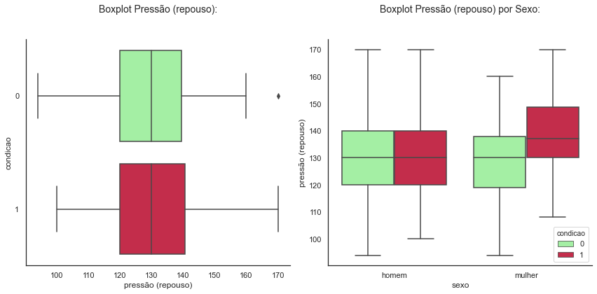

```python
sns.set_style('white')
fig, ax = plt.subplots(1,2, figsize=(12,6))


sns.boxplot(y='condicao',x='pressão (repouso)', data=df, ax=ax[0], orient='h', palette=colors)
sns.boxplot(x='sexo', y='pressão (repouso)', hue='condicao', data=df, palette=colors, ax=ax[1])

ax[0].set_title('Boxplot Pressão (repouso):\n\n', fontsize=14)
ax[1].set_title('Boxplot Pressão (repouso) por Sexo:\n\n', fontsize=14)


sns.despine()
plt.tight_layout()
plt.show()
```

Confirmando nossa suspeita, o primeiro boxplot nos mostra que praticamente não há diferença entre as pressões em repouso para pacientes com e sem doenças cardiacas. Ao dividirmos este dado por sexo, percebemos que a unica diferença aparente são para pacientes mulheres positivas para doenças cardiacas (que apresentam pressão relativamente mais alta que os outros grupos). Logo, podemos considerar que pressão (repouso) elevada pode ser um bom indicador de doenças cardiacas para mulheres.

**Colesterol (chol)**

Nível de colesterol "total" do paciente em mg/dl. Infelizmente o dataset não faz uma diferenciação entre LDL (lipoproteína de baixa densidade, o colesterol "ruim"), HDL (lipoproteína de alta densidade, o colesterol "bom") e VLDL (lipoproteína de densidade muito baixa, partículas que eventualmente se tornam LDL). Altos níveis de LDL estão correlacionados a formação de Placas de Ateroma, trombos e doenças cardíacas enquanto altos níveis de HDL, por outro lado, podem ser relacionados a atividades anti-trombóticas, anti-oxidantes e anti-inflamatórias.

O valor de referência desejável para o colesterol total é abaixo de 190 mg/dL.

Fontes:

https://saude.abril.com.br/medicina/o-que-e-o-colesterol-ldl-e-o-hdl/

http://hermespardini.com.br/blog/?p=76

https://saude.estadao.com.br/noticias/geral,cardiologistas-brasileiros-estabelecem-valores-mais-rigidos-de-colesterol-ruim,70001933579

Com isso, também podemos criar uma coluna classificatória de colesterol alto ou normal/baixo para ajudar na análise exploratória de dados de nosso dataset.

**Class colesterol**

```python
df['class colesterol'] = 'classificação de colesterol'

for idx, _ in df.iterrows():
    if df.loc[idx, 'colesterol'] < 190:
        df.loc[idx,'class colesterol'] = 'normal/baixo'
    elif df.loc[idx, 'colesterol'] >= 190:
        df.loc[idx,'class colesterol'] = 'alto'

df['class colesterol'] = pd.Categorical(df['class colesterol'])
df['class colesterol'].unique()
```

```
['alto', 'normal/baixo']
Categories (2, object): ['alto', 'normal/baixo']
```

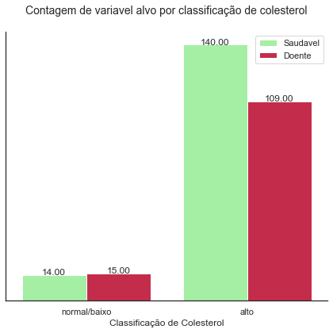

```python
sns.set_style('white')
plt.figure(figsize=(6,6))

ax = sns.countplot('class colesterol', hue='condicao', data=df,
                   palette=colors,
                   order=['normal/baixo','alto'])

show_values_on_bars(ax)

plt.title('Contagem de variavel alvo por classificação de colesterol\n', fontdict={'size':14})
plt.yticks(ticks=[])
plt.ylabel('')
plt.legend(['Saudavel','Doente'])
plt.xlabel('Classificação de Colesterol')
sns.despine()
plt.tight_layout()
plt.show()
```

```python
print(f"Pacientes com colesterol normal/baixo: {len(df[df['class colesterol'] == 'normal/baixo'])}")
```

```
Pacientes com colesterol normal/baixo: 29
```

```python
print(f"Pacientes com colesterol alto: {len(df[df['class colesterol'] == 'alto'])}")
```

```
Pacientes com colesterol alto: 249
```

Com a contagem de pacientes por classificação de colesterol, podemos ver que a maior parte de nossos pacientes possui colesterol alto independente de ter ou não doença cardíaca. Já a contagem de pacientes com colesterol normal/baixo é praticamente igual para saudáveis e doentes. Esperávamos que colesterol fosse ser um bom indicador de doenças cardíacas, mas talvez não seja o caso neste dataset. Vamos nos aprofundar:

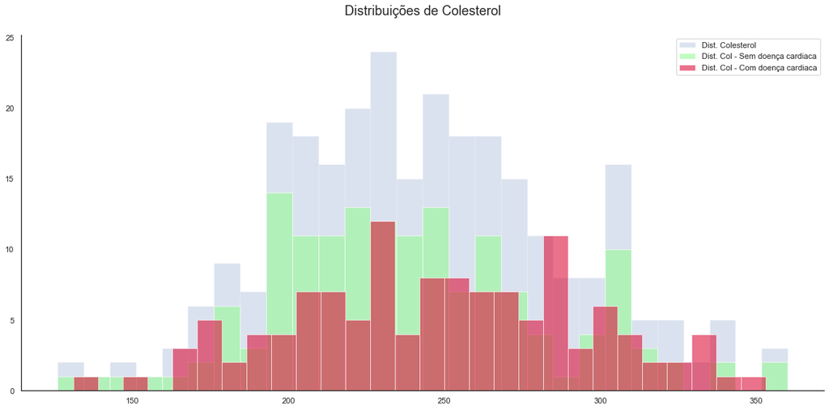

```python
sns.set_style('white')

plt.figure(figsize=(16,8))
sns.distplot(df['colesterol'],  kde=False, bins=28, color='b',
             hist_kws=dict(alpha=.2), label="Dist. Colesterol")

sns.distplot(df[df['condicao']==0]['colesterol'], kde=False, bins=28, color='palegreen',
             hist_kws=dict(alpha=.6),label="Dist. Col - Sem doença cardiaca")

sns.distplot(df[df['condicao']==1]['colesterol'], kde=False, bins=28, color='crimson',
             hist_kws=dict(alpha=.6),label="Dist. Col - Com doença cardiaca")


plt.title('Distribuições de Colesterol\n',  fontdict={'size':18})
plt.xlabel('')
plt.legend()

sns.despine()
plt.tight_layout()
plt.show()
```

A distribuição de níveis de colesterol parece ser parecida entre ambos grupos, com o grupo positivo para doenças cardíacas apresentando valores mais altos.

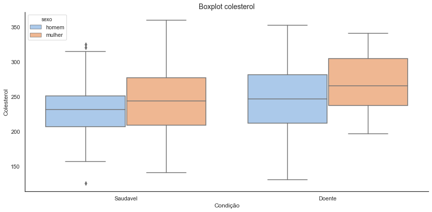

```python
sns.set_style('white')
plt.figure(figsize=(12,6))

sns.boxplot(x='condicao',y='colesterol', hue='sexo', data=df, palette='pastel')

plt.title('Boxplot colesterol', fontdict={'size':14})
plt.ylabel('Colesterol')
plt.xlabel('Condição')

plt.xticks(ticks=[0,1], labels=['Saudavel','Doente'])
sns.despine()
plt.tight_layout()
plt.show()
```

Como esperado depois do histograma, podemos ver que existe de fato uma diferença (apesar de pequena) entre os níveis de colesterol de pacientes 0 e 1. Também existe uma diferença entre sexos, com mulheres apresentando colesterol mais altos em ambos os grupos.

Abaixo, podemos analisar as medianas de cada grupo:

```python
print(
 "Mediana da coluna COLESTEROL: {}\n\n"
 "Mediana de COLESTEROL para pacientes saudaveis: {}\n"
 "Mediana de COLESTEROL para pacientes doentes: {}\n\n"
 "Mediana de COLESTEROL para homens: {}\n"
 "Mediana de COLESTEROL para homens doentes {}\n"
 "Mediana de COLESTEROL para homens saudaveis {}\n\n"
 "Mediana de COLESTEROL para mulheres: {}\n"
 "Mediana de COLESTEROL para mulheres doentes {}\n"
 "Mediana de COLESTEROL para mulheres saudaveis {}\n".format(
     df['colesterol'].median(),
     df[df['condicao'] == 0]['colesterol'].median(),
     df[df['condicao'] == 1]['colesterol'].median(),
     df[df['sexo'] == 'homem']['colesterol'].median(),
     df[(df['sexo'] == 'homem') & (df['condicao'] == 1)]['colesterol'].median(),
     df[(df['sexo'] == 'homem') & (df['condicao'] == 0)]['colesterol'].median(),
     df[df['sexo'] == 'mulher']['colesterol'].median(),
     df[(df['sexo'] == 'mulher') & (df['condicao'] == 1)]['colesterol'].median(),
     df[(df['sexo'] == 'mulher') & (df['condicao'] == 0)]['colesterol'].median()))
```

```
Mediana da coluna COLESTEROL: 240.0

Mediana de COLESTEROL para pacientes saudaveis: 234.5
Mediana de COLESTEROL para pacientes doentes: 249.0

Mediana de COLESTEROL para homens: 235.0
Mediana de COLESTEROL para homens doentes 247.0
Mediana de COLESTEROL para homens saudaveis 232.0

Mediana de COLESTEROL para mulheres: 250.0
Mediana de COLESTEROL para mulheres doentes 265.5
Mediana de COLESTEROL para mulheres saudaveis 244.0
```

Mulheres, tanto docentes quanto saudáveis, tendem a apresentar colesterol mais alto que homens.

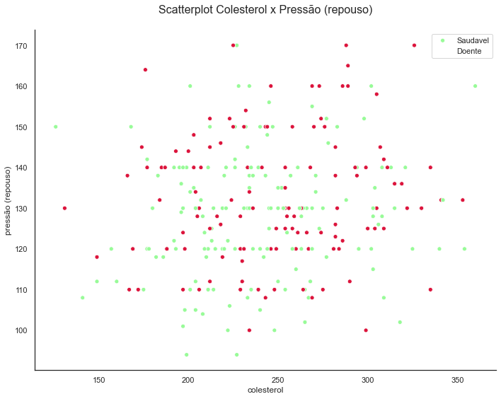

```python
sns.set_style('white')
plt.figure(figsize=(10,8))

sns.scatterplot(x='colesterol',y='pressão (repouso)', data=df, hue='condicao', palette=colors)

plt.title('Scatterplot Colesterol x Pressão (repouso)\n',fontdict={'size':16})
sns.despine()
plt.legend(['Saudavel','Doente'])
plt.tight_layout()
plt.show()
```

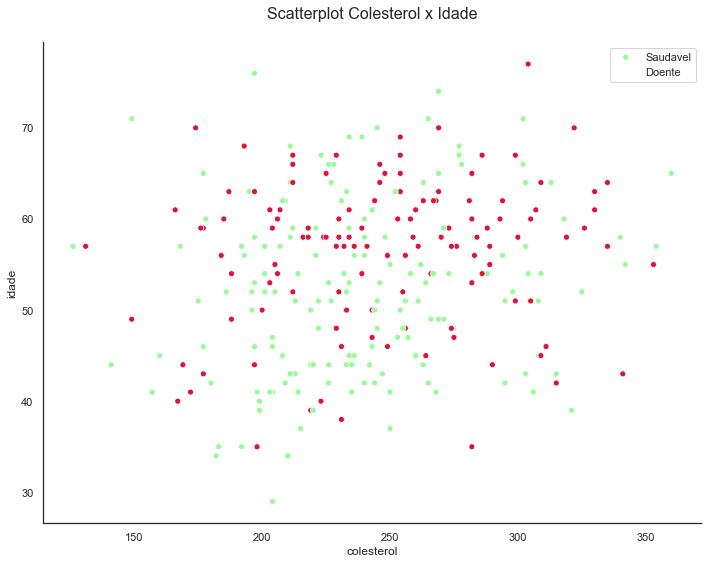

```python
sns.set_style('white')
plt.figure(figsize=(10,8))

sns.scatterplot(x='colesterol',y='idade',data=df, hue='condicao', palette=colors)

plt.title('Scatterplot Colesterol x Idade\n',fontdict={'size':16})
sns.despine()
plt.legend(['Saudavel','Doente'])
plt.tight_layout()
plt.show()
```

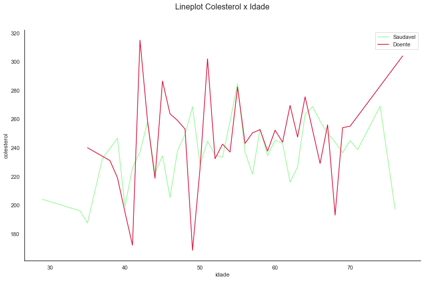

```python
sns.set_style('white')
plt.figure(figsize=(12,8))
sns.lineplot(x='idade',y='colesterol', data=df, hue='condicao', palette=colors, ci=None)
plt.title('Lineplot Colesterol x Idade\n\n', fontdict={'size':16})

plt.legend(['Saudavel','Doente'])
sns.despine()
plt.tight_layout()
plt.show()
```

Estranhamente, os gráficos entre colesterol e pressão (repouso) e colesterol e idade não apresentam tendências claras.

Considerando que o valor considerado saudável é igual ou menor que 190mg/dL, é importante notar que a mediana de colesterol de TODOS os grupos analisados até aqui (com ou sem doença e por sexos) é consideravelmente maior que este valor. Essa alta generalizada de colesterol dos pacientes de nosso dataset pode (e provavelmente vai) acabar diminuindo a importância bibliograficamente comprovada da influencia dos níveis de colesterol em doenças cardíacas.

Aqui cabe uma discussão mais extensa sobre os estilos de vida da população onde o estudo foi realizado (Cleveland - EUA).

**Glicose em jejum (fbs - fasting blood sugar)**

0 = valor menor que 120mg/dl

1 = valor maior que 120mg/dl

Níveis de glicose em jejum. Valores altos podem indicar diabetes, condição altamente correlacionada com doenças cardíacas. Valores considerados normais são:

Abaixo de 100mg/dl: Normal Até 125mg/dl: Pré-diabetes Acima de 126mg/dl: Diabetes

Neste dataframe, a única informação que temos é se o paciente possui um valor acima ou abaixo de 120mg/dl. Com esse dado, não podemos afirmar que o paciente é ou não é diabetico, somente considerar que o mesmo possui ou não possui altos níveis de glicose em jejum.

Alterarei os valores para "menor que 120mg" e "maior que 120mg" para tornar a fase de EDA mais descritiva.

Fonte: https://www.cdc.gov/diabetes/library/features/diabetes-and-heart.html

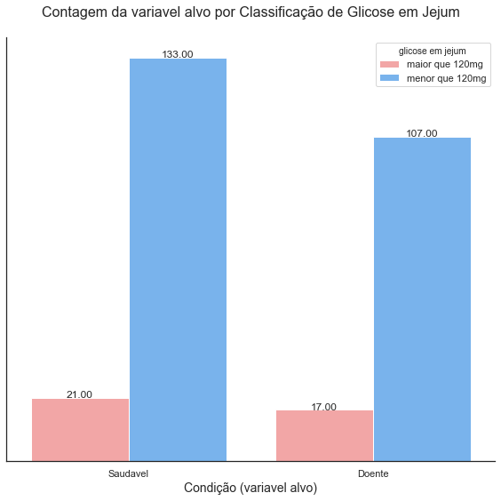

```python
sns.set_style('white')
plt.figure(figsize=(8,8))
colors = ['#ff9999','#66b3ff']
ax = sns.countplot('condicao',hue='glicose em jejum',data=df, palette=colors)
show_values_on_bars(ax)

plt.ylabel('')
plt.xlabel('Condição (variavel alvo)', fontdict={'size':14})
plt.title('Contagem da variavel alvo por Classificação de Glicose em Jejum\n', fontdict={'size':16})
plt.yticks(ticks=[])
plt.xticks(ticks=[0,1], labels=['Saudavel','Doente'])

sns.despine()
plt.tight_layout()
plt.show()
```

Novamente, temos uma distribuição muito parecida entre ambos os grupos. A variável Glicose em Jejum é bem balanceada entre doentes e não-doentes. Parece que não será um bom indicador de doenças cardíacas por si só.

**ECG em repouso (restecg: resting electrocardiographic results)**

Resultados do exame de eletrocardiograma realizado em repouso.

0 = Normal

1 = Anormalidade no segmento ST ou onda T do eletrocardiograma

2 = Hipertrofia ventricular segundo criterio de Estes (https://en.ecgpedia.org/wiki/Romhilt-Estes_Score)

Pacientes com quadros menos graves tendem a apresentar anormalidades somente durante atividades de estresse. Resultados de ECG anormais em situação de repouso podem ser indicativos de um possível quadro mais grave de doença cardíaca. O segmento ST representa o período de inatividade elétrica depois do miocárdio estar despolarizado enquanto a onda T representa a repolarização dos ventrículos.

As alterações do segmento ST/onda T são de grande importância no diagnóstico das síndromes coronarianas agudas. A imagem abaixo compara um ECG normal com exemplos de variação ST-T:

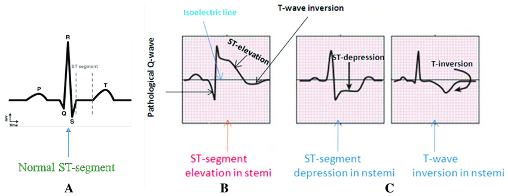

Pacientes que apresentarem valor "2" nesta coluna foram diagnosticados com hipertrofia ventricular. Pressão alta e doenças cardíacas aumentam o esforço cardíaco necessário para manter o funcionamento do corpo. Sendo um músculo, esse aumento de esforço causa uma hipertrofia (geralmente presente no ventrículo esquerdo). Apesar de ser uma condição altamente correlacionada com quadros de patologia cardiaca, hipertrofias ventriculares também podem ser encontradas em atletas de alto nível.

Nesta variável, manterei os valores como 0, 1 e 2, pois é importante que haja a intuição que um quadro de hipertrofia ventricular é "mais grave" que somente presença de anormalidade de ST. Fontes:

https://www.mayoclinic.org/diseases-conditions/left-ventricular-hypertrophy/symptoms-causes/syc-20374314

https://pebmed.com.br/sindrome-coronariana-com-supra-st-como-avaliar-o-eletrocardiograma/

https://www.researchgate.net/figure/Comparison-of-the-ST-segment-variations-in-a-normal-subject-A-and-in-MI-patients-with_fig1_333912486

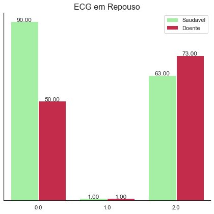

```python
sns.set_style('white')
plt.figure(figsize=(6,6))

colors = ['palegreen','crimson']
ax = sns.countplot('ECG em repouso', hue='condicao', data=df, palette=colors)
show_values_on_bars(ax)

plt.title('ECG em Repouso', fontdict={'size':16})
plt.ylabel('')
plt.xlabel('')
plt.yticks(ticks=[])

plt.legend(['Saudavel','Doente'])
plt.tight_layout()
sns.despine()
plt.show()
```

Parece que temos pouquíssimos pacientes na categoria 1 (Anormalidade no segmento ST ou onda T do eletrocardiograma). A existência de uma categoria com tão poucos pacientes pode acabar atrapalhando nosso modelo. Vamos remover estes pacientes do dataframe.

```python
drop_ecg = df[df['ECG em repouso'] == 1].index
```

```python
df = df.drop(drop_ecg, axis=0)
```

```python
df['ECG em repouso'] = df['ECG em repouso'].cat.remove_unused_categories()
```

```python
df['ECG em repouso'] = df['ECG em repouso'].replace({0:'normal',2:'hipertrofia ventricular'})
```

```python
df['ECG em repouso'] = pd.Categorical(df['ECG em repouso'])
df['ECG em repouso'].unique()
```

```
['hipertrofia ventricular', 'normal']
Categories (2, object): ['hipertrofia ventricular', 'normal']
```

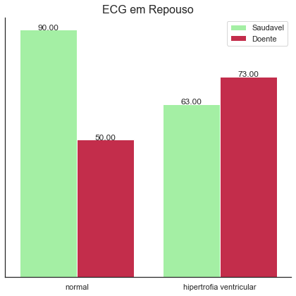

```python
sns.set_style('white')
plt.figure(figsize=(6,6))

ax = sns.countplot('ECG em repouso', hue='condicao', data=df, palette=colors, order=['normal','hipertrofia ventricular'])
show_values_on_bars(ax)

plt.title('ECG em Repouso', fontdict={'size':16})
plt.ylabel('')
plt.xlabel('')
plt.yticks(ticks=[])

plt.legend(['Saudavel','Doente'])
plt.tight_layout()
sns.despine()
plt.show()
```

Como explicado no início do notebook os valores da variável ECG em repouso (0, 1 e 2) representam respectivamente:

0 = Normal

1 = Anormalidade no segmento ST ou onda T do eletrocardiograma (agora removidos)

2 = Hipertrofia ventricular

Apesar de os valores entre pacientes doentes e saudáveis na categoria de hipertrofia ventricular serem relativamente parecidos (havendo mais pacientes doentes que saudáveis, como esperado), o que mais chama atenção neste gráfico é a suposta "proteção" que possuir um ECG em repouso normal pode conceder a um paciente. Em pacientes com ECG normal, temos quase o dobro de saudáveis do que doentes.

**Frequência cardíaca máxima em stress (thalach: maximum heart rate achieved)**

Valor da frequência cardíaca máxima durante estresse em bpm. O cálculo feito para encontrar o valor máximo é 220 - Idade. Isso significa é que é comum para pacientes mais jovens terem a frequência máxima mais alta.

Contudo, o valor de um paciente ser mais baixo que o 220 - Idade não significa necessariamente patologia. A taxa ideal para um exercício moderado é de 50% até 70% de sua frequência cardíaca máxima, enquanto para exercícios intensos, a taxa ideal é até 85%. Esta é uma variável complicada de interpretar, pois não temos informações sobre o nível (e duração) do exercício (estresse) ao qual o paciente foi induzido.

Descobriremos mais sobre essa variável durante a EDA.

Fontes:

https://www.healio.com/cardiology/learn-the-heart/cardiology-review/topic-reviews/stress-testing-review

https://www.health.harvard.edu/heart-health/what-your-heart-rate-is-telling-you

https://www.heart.org/en/healthy-living/fitness/fitness-basics/target-heart-rates

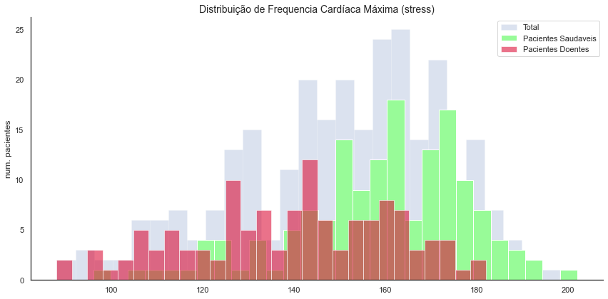

```python
sns.set_style('white')
plt.figure(figsize=(12,6))


sns.distplot(df['frequência cardíaca máxima (stress)'], kde=False, bins=28, color='b',
             hist_kws=dict(alpha=.2), label="Total")

sns.distplot(df[df['condicao'] == 0]['frequência cardíaca máxima (stress)'], kde=False, bins=28, color='palegreen',
             hist_kws=dict(alpha=1), label="Pacientes Saudaveis")
sns.distplot(df[df['condicao'] == 1]['frequência cardíaca máxima (stress)'], kde=False, bins=28, color='crimson',
             hist_kws=dict(alpha=0.6), label="Pacientes Doentes")

plt.title('Distribuição de Frequencia Cardíaca Máxima (stress)', fontdict={'size':14})
plt.xlabel('')
plt.ylabel('num. pacientes')
plt.legend()
sns.despine()
plt.tight_layout()
plt.show()
```

Aparentemente, a frequência cardíaca máxima dos pacientes saudáveis é maior do que a de pacientes acometidos por doenças cardíacas. Há várias maneiras de se olhar para esse resultado:

Por um lado, esperamos frequências cardíacas mais altas de pacientes com corações comprometidos, pois o coração teria que trabalhar mais duro para bombear a quantidade necessária de sangue durante exercício físico como forma de compensar seu mal funcionamento.

Por outro lado, vimos acima que na distribuição de idades que pacientes sem doenças cardíacas tendem a ser mais jovens, e sabendo que o cálculo de frequência cardíaca máxima ideal é 220 - Idade, faz sentido que a distribuição para pacientes sem doenças cardíacas (presumindo que estes pacientes "saudáveis" possuem valor de frequencia máxima próximo do ideal) possua valores maiores.

```python
print(f"Mediana de Idade de pacientes saudaveis: {df[df['condicao'] == 0]['idade'].median()}")
print(f"Mediana de Idade de pacientes doentes: {df[df['condicao'] == 1]['idade'].median()}")
```

```
Mediana de Idade de pacientes saudaveis: 52.0
Mediana de Idade de pacientes doentes: 58.0
```

De fato, a mediana de idade dos pacientes doentes possui um valor maior do que a dos saudáveis, mas a diferença não é grande o suficiente para sozinha explicar a distribuição mais elevada de Frequencia Cardiaca Maxima.

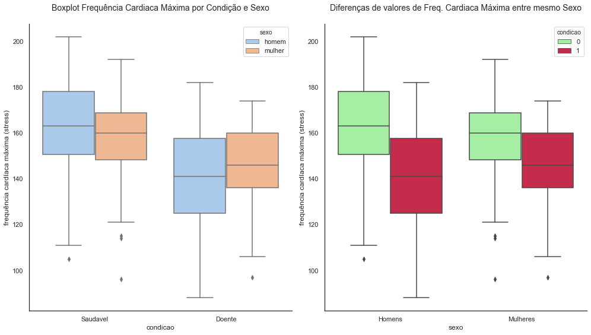

```python
sns.set_style('white')
fig, ax = plt.subplots(1,2,figsize=(14,8))

sns.boxplot(y='frequência cardíaca máxima (stress)',x='condicao', hue='sexo', data=df, orient='v', palette='pastel', ax=ax[0])
sns.boxplot(y='frequência cardíaca máxima (stress)',x='sexo', hue='condicao', data=df, orient='v', palette=colors, ax=ax[1])

ax[0].set_title('Boxplot Frequência Cardiaca Máxima por Condição e Sexo\n', fontdict={'size':14})
ax[1].set_title('Diferenças de valores de Freq. Cardiaca Máxima entre mesmo Sexo\n', fontdict={'size':14})

plt.sca(ax[0])
plt.xticks(range(2), ['Saudavel','Doente'])

plt.sca(ax[1])
plt.xticks(range(2), ['Homens','Mulheres'])


plt.tight_layout()
sns.despine()
plt.show()
```

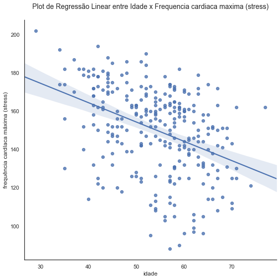

```python
sns.set_style('white')

sns.lmplot(x='idade', y='frequência cardíaca máxima (stress)', data=df, height=8)
ax = plt.gca()
ax.set_title("Plot de Regressão Linear entre Idade x Frequencia cardiaca maxima (stress)\n", fontdict={'size':14})

plt.tight_layout()
plt.show()
```

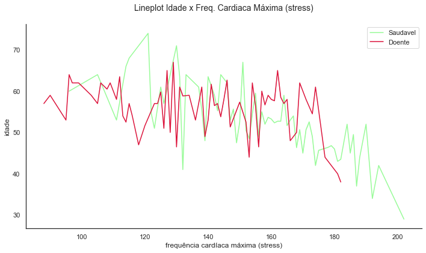

```python
plt.figure(figsize=(10,6))
sns.lineplot(x='frequência cardíaca máxima (stress)', y='idade',hue='condicao', data=df, ci=False, palette=colors)


plt.title('Lineplot Idade x Freq. Cardiaca Máxima (stress)\n', fontdict={'size':14})
plt.legend(['Saudavel','Doente'])
plt.tight_layout()
sns.despine()
plt.show()
```

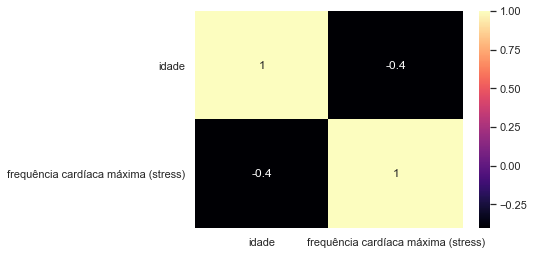

```python
sns.heatmap(df[['idade','frequência cardíaca máxima (stress)']].corr(), annot=True, cmap='magma')
plt.yticks(rotation=0)

plt.show()
```

A regressão linear e o mapa de calor nos mostra que de fato, existe uma correlação negativa, mesmo que relativamente baixa (-0.41) entre frequencia cardiaca maxima (stress) e idade.